# RMA - Dunnhumby Data

Jason Darsono

2023-04-04

# Read Cincinnati Store File

```r
# Load Dataset
data <- read_csv("data25027.csv")
head(data)
```

```
## # A tibble: 6 × 44
##   WEEK_END_DATE STORE_NUM     UPC UNITS VISITS   HHS SPEND PRICE BASE_…¹ FEATURE
##   <date>            <dbl>   <dbl> <dbl>  <dbl> <dbl> <dbl> <dbl>   <dbl>   <dbl>
## 1 2009-01-14        25027  1.11e9   166    151   149  229.  1.38    1.49       0
## 2 2009-01-21        25027  1.11e9   175    156   154  241.  1.38    1.49       0
## 3 2009-01-28        25027  1.11e9   158    144   139  218.  1.38    1.49       0
## 4 2009-02-04        25027  1.11e9   184    163   163  252.  1.37    1.49       0
## 5 2009-02-11        25027  1.11e9   199    170   164  295.  1.48    1.49       0
## 6 2009-02-18        25027  1.11e9   176    154   150  259.  1.47    1.49       0
## # … with 34 more variables: DISPLAY <dbl>, TPR_ONLY <dbl>, UPV <dbl>,
## #   VPH <dbl>, UPH <dbl>, DESCRIPTION <chr>, MANUFACTURER <chr>,
## #   CATEGORY <chr>, SUB_CATEGORY <chr>, PRODUCT_SIZE <chr>, TYPE <chr>,
## #   DISCOUNT <dbl>, DISC_RATE <dbl>, PREV_PROMO <chr>, PREV_SALES <dbl>,
## #   PREV_PRICE <dbl>, PREV_UPV <dbl>, AVG_SALES <dbl>, SALES_INC <dbl>,
## #   SALES_INC_RATE <dbl>, PRICE_BIN <chr>, DISC_BIN <chr>, SALES_INC_BIN <chr>,
## #   UPV_CHG <dbl>, STORE_ID <dbl>, STORE_NAME <chr>, ADDRESS_CITY_NAME <chr>, …
```

We know from our data explorations that the available categories are “BAG SNACKS”, “ORAL HYGIENE PRODUCTS”, “COLD CEREAL” and “FROZEN PIZZA”.

We select “ORAL HYGIENE PRODUCTS” category in our deep-dive analysis, focusing on mouthwash products with large sizes (more than or equal to 1L). For this, we have the few products that we can analyse as follows:

- **Product 1**
  - UPC: 1111035398
  - Product Description: PL BL MINT ANTSPTC RINSE
  - Manufacturer: PRIVATE LABEL
  - Product size: 1.5L
- **Product 2**
  - UPC: 3700031613
  - Product Description: SCOPE ORIG MINT MOUTHWASH
  - Manufacturer: P & G
  - Product size: 1L
- **Product 3**
  - UPC: 3700044982
  - Product Description: CREST PH CLN MINT RINSE
  - Manufacturer: P & G
  - Product size: 1L
- **Product 4**
  - UPC: 31254742735
  - Product Description: LSTRNE CL MINT ANTSPTC MW
  - Manufacturer: WARNER
  - Product size: 1L
- **Product 5**
  - UPC: 31254742835
  - Product Description: LSTRNE FRS BRST ANTSPC MW
  - Manufacturer: WARNER
  - Product size: 1L

We will analyse the sales of mouthwash in Cincinnati store, Ohio using two marketing mix modelling as follows:

1. SCAN*PRO model

$$q_{kjt} =
[\prod^{n}_{r=1}(\frac{p_{krt}}{\bar{p}_{kr}})^{\beta rj}
\prod^{3}_{l=1}\gamma_{lrj}^{D_{lkrt}}][\prod^{T}_{t=1}\delta_{jt}^{X_t}][\prod^{K}_{k=1}\lambda_{kj}^{Z_k}]e^{u_{kjt}}$$

Simplifying the model, we only consider a single store (ID: 25027) and take each individual UPC to be its own “brand”. Therefore, our SCAN*PRO is as follows:

$$q_{jt} =
[\prod^{5}_{r=1}(\frac{p_{rt}}{\bar{p}_{r}})^{\beta rj}
\prod^{3}_{l=1}\gamma_{lrj}^{D_{lrt}}][\prod^{52}_{t=1}\delta_{jt}^{X_t}]e^{u_{jt}}$$

Taking the log-transformation, we then have a linear model which we can apply OLS to study the effect of each promotional campaign.

$$ln(q_{jt}) = \sum^{5}_{r=1} \beta_{rj}
ln(\frac{p_{rt}}{\bar{p}_{r}}) + \sum^{5}_{r=1} \sum^{3}_{l=1}
\gamma_{lrj}' D_{lrt}+\sum^{52}_{t=1} \delta_{jt}' X_{t} +
\epsilon_{jt}$$

Finally we have our estimator expressed as follows:

$$\widehat{ln(q_{j})} = \sum^{5}_{r=1}
\hat{\beta_{rj}} \ln(\text{PI}) + \sum^{5}_{r=1} \sum^{3}_{l=1}
\hat{\gamma_{lrj}}' D_{lr}+\sum^{51}_{t=1} \hat{\delta_{jt}}'
X_{t}$$
Where $\text{PI}=\frac{p_{r}}{\bar{p}_{r}}$.

```r
# filter the data with the mouthwash products using selected UPC
selected_upcs <- c(1111035398, 3700031613, 3700044982, 31254742735, 31254742835)

data_mw <- data %>%
  filter(CATEGORY == "ORAL HYGIENE PRODUCTS",
         UPC %in% selected_upcs) %>%
  mutate(WEEK = week(ymd(WEEK_END_DATE)),
         PRODUCT = case_when(UPC == 1111035398 ~ "Product1",
                             UPC == 3700031613 ~ "Product2",
                             UPC == 3700044982 ~ "Product3",
                             UPC == 31254742735 ~ "Product4",
                             UPC == 31254742835 ~ "Product5")) %>%
  select(WEEK_END_DATE, UPC, WEEK, PRODUCT,
         UNITS, PRICE, FEATURE, DISPLAY) %>%
  arrange(WEEK_END_DATE, UPC)
```

```r
# get the median price of the products
median_prices <- data_mw %>%
  group_by(PRODUCT) %>%
  summarise(MEDIAN = median(PRICE))

# merge median price into main dataframe
# calculate for log of price, log of sales
# and get indicators for feature only, display only or combination of both
data_mw2 <- merge(data_mw, median_prices, by="PRODUCT") %>%
  select(WEEK_END_DATE, UPC, WEEK, PRODUCT,
         UNITS, PRICE, FEATURE, DISPLAY, MEDIAN) %>%
  mutate(PRICEIDX = PRICE / MEDIAN,
         LNPRICEIDX = log(PRICEIDX),
         LNSALES = log(UNITS),
         FEATUREONLY = ifelse((FEATURE==1)&(DISPLAY==0), 1, 0),
         DISPLAYONLY = ifelse((FEATURE==0)&(DISPLAY==1), 1, 0),
         COMBINATION = ifelse((FEATURE==1)&(DISPLAY==1), 1, 0)) %>%
  arrange(WEEK_END_DATE, UPC)

# pivot wide the independent variables such as sales, price, feature, display and combination
wide_data <- data_mw2 %>%
  pivot_wider(id_cols=WEEK_END_DATE, names_from=PRODUCT, names_sort = TRUE,
              values_from=c(LNSALES, LNPRICEIDX, FEATUREONLY, DISPLAYONLY, COMBINATION))

# pivot wide the week indicators
week_wide <- data_mw2 %>%
  pivot_wider(id_cols=WEEK_END_DATE, names_from=WEEK, names_sort = TRUE, names_prefix="WEEK_",
              values_from=WEEK,values_fill=0, values_fn = function(x){ifelse(length(x) >= 1, 1, 0)})

# merge all independent variables into one by date
wide_data2 <- wide_data %>%
  merge(week_wide, by="WEEK_END_DATE")
```

## Check for missing values

We check if there are any missing data. Missing data indicates unsuitable for time-series analysis.

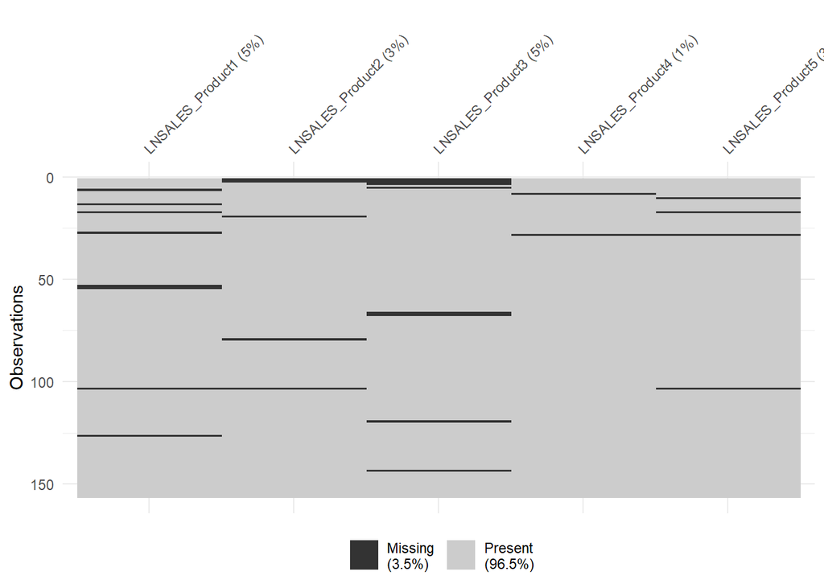

```r
# visualise if there is any missing data
vis_miss(wide_data2[,2:6])
```

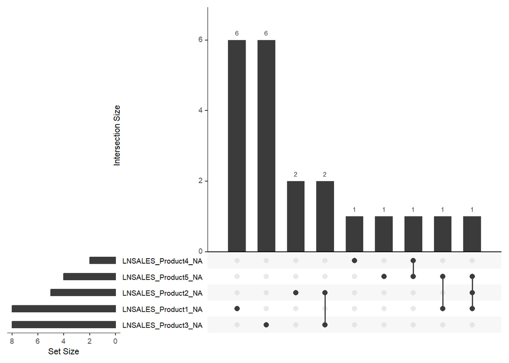

```r
gg_miss_upset(wide_data2[,2:6])
```

## Check for collinearity

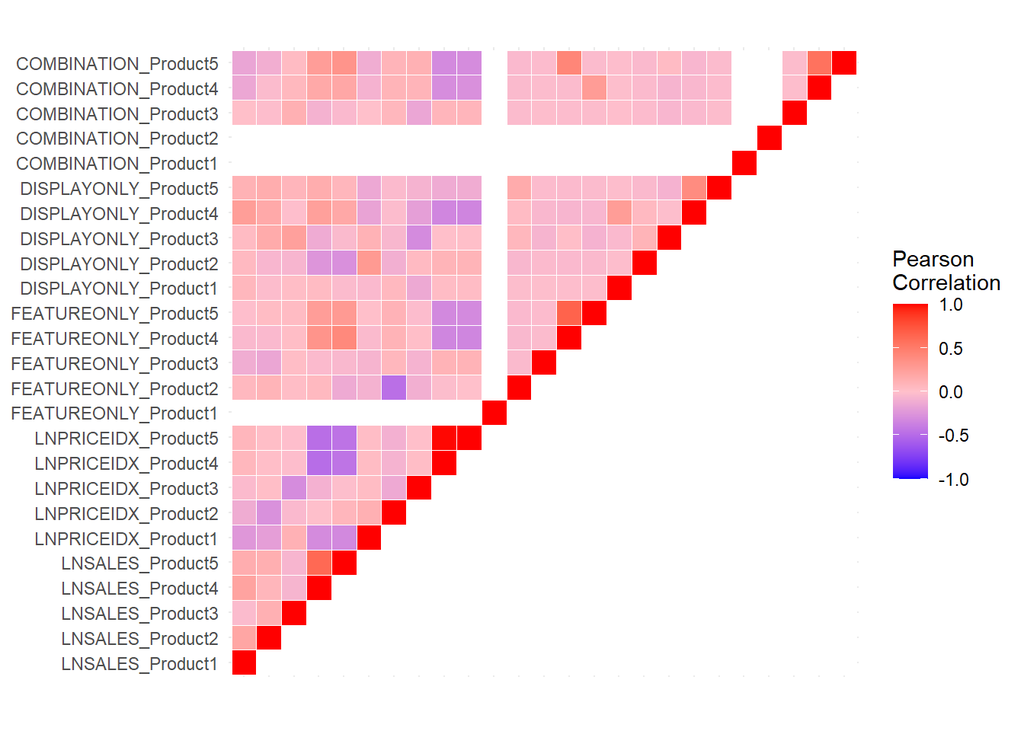

```r
cormat <- round(cor(drop_na(wide_data2[,2:26])), 3)
cormat[lower.tri(cormat)]<- NA
melted_cormat <- melt(cormat, na.rm=T)

ggheatmap <- ggplot(melted_cormat, aes(X1, X2, fill = value)) +
 geom_tile(color = "white") +
 scale_fill_gradient2(low = "blue", mid = "pink", high = "red",
                      midpoint = 0, limit = c(-1,1), space = "Lab",
                      na.value = "white", name="Pearson\nCorrelation") +
 theme_minimal() +
 theme(axis.title=element_blank(),
       axis.text.x=element_blank()) +
 coord_fixed()

print(ggheatmap)
```

Close to perfect collinearity observed between price of product4 and product5, with correlation of 0.994.

```r
cor(drop_na(wide_data2[,c(10,11)]))
```

```
##                     LNPRICEIDX_Product4 LNPRICEIDX_Product5
## LNPRICEIDX_Product4            1.000000            0.993628
## LNPRICEIDX_Product5            0.993628            1.000000
```

Price movements are also identicall between the two.

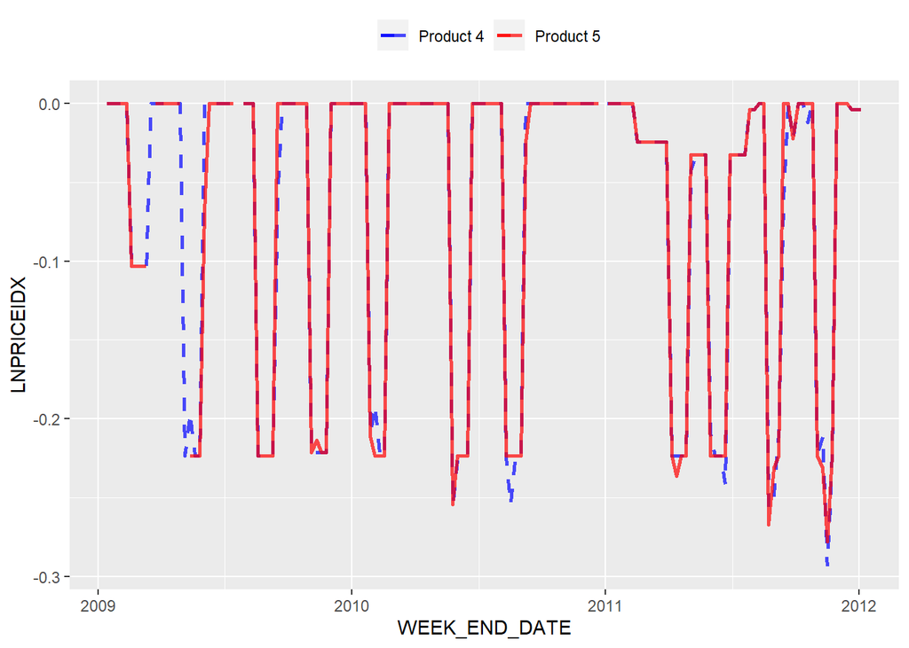

```r
ggplot(data=wide_data2) +
  geom_line(aes(x=WEEK_END_DATE, y=LNPRICEIDX_Product4, color="blue"), linewidth=1, linetype="dashed", alpha=0.7) +
  geom_line(aes(x=WEEK_END_DATE, y=LNPRICEIDX_Product5, color="red"), linewidth=1, linetype="solid", alpha=0.7) +
  scale_color_manual(name="", labels=c("Product 4", "Product 5"), values=c("blue", "red"), breaks=c("blue", "red")) +
  theme(legend.position = "top") +
  labs(y="LNPRICEIDX")
```

Therefore, we decided to average out the price index movements i.e. the log of price index of product 4 and product 5.

```r
# average out the price movements
wide_data2$LNPRICEIDX_Product45 <- rowMeans(wide_data2[,c("LNPRICEIDX_Product4", "LNPRICEIDX_Product5")])
```

# 1. SCAN*PRO model

Fit all the relevant variables into the OLS regression to get the SCAN*PRO model.

```r
fit1 <- lm(LNSALES_Product1 ~ LNPRICEIDX_Product1 + LNPRICEIDX_Product2 + LNPRICEIDX_Product3 +
                     LNPRICEIDX_Product45 + DISPLAYONLY_Product1 +
                     WEEK_1 + WEEK_2 + WEEK_3 + WEEK_4 + WEEK_5 + WEEK_6 + WEEK_7 + WEEK_8 +
                     WEEK_9 + WEEK_10 + WEEK_11 + WEEK_12 + WEEK_13 + WEEK_14 + WEEK_15 + WEEK_16 + WEEK_17 +
                     WEEK_18 + WEEK_19 + WEEK_20 + WEEK_21 + WEEK_22 + WEEK_23 + WEEK_24 + WEEK_25 + WEEK_26 +
                     WEEK_27 + WEEK_28 + WEEK_29 + WEEK_30 + WEEK_31 + WEEK_32 + WEEK_33 + WEEK_34 + WEEK_35 +
                     WEEK_36 + WEEK_37 + WEEK_38 + WEEK_39 + WEEK_40 + WEEK_41 + WEEK_42 + WEEK_43 + WEEK_44 +
                     WEEK_45 + WEEK_46 + WEEK_47 + WEEK_48 + WEEK_49 + WEEK_50 + WEEK_51,
                   data = drop_na(wide_data2))

fit2 <- lm(LNSALES_Product2 ~ LNPRICEIDX_Product1 + LNPRICEIDX_Product2 + LNPRICEIDX_Product3 +
                     LNPRICEIDX_Product45 + DISPLAYONLY_Product2 + FEATUREONLY_Product2 +
                     WEEK_1 + WEEK_2 + WEEK_3 + WEEK_4 + WEEK_5 + WEEK_6 + WEEK_7 + WEEK_8 +
                     WEEK_9 + WEEK_10 + WEEK_11 + WEEK_12 + WEEK_13 + WEEK_14 + WEEK_15 + WEEK_16 + WEEK_17 +
                     WEEK_18 + WEEK_19 + WEEK_20 + WEEK_21 + WEEK_22 + WEEK_23 + WEEK_24 + WEEK_25 + WEEK_26 +
                     WEEK_27 + WEEK_28 + WEEK_29 + WEEK_30 + WEEK_31 + WEEK_32 + WEEK_33 + WEEK_34 + WEEK_35 +
                     WEEK_36 + WEEK_37 + WEEK_38 + WEEK_39 + WEEK_40 + WEEK_41 + WEEK_42 + WEEK_43 + WEEK_44 +
                     WEEK_45 + WEEK_46 + WEEK_47 + WEEK_48 + WEEK_49 + WEEK_50 + WEEK_51,
                   data = drop_na(wide_data2))

fit3 <- lm(LNSALES_Product3 ~ LNPRICEIDX_Product1 + LNPRICEIDX_Product2 + LNPRICEIDX_Product3 +
                     LNPRICEIDX_Product45 + DISPLAYONLY_Product3 + FEATUREONLY_Product3 +
                     COMBINATION_Product3 + WEEK_1 + WEEK_2 + WEEK_3 + WEEK_4 + WEEK_5 + WEEK_6 + WEEK_7 + WEEK_8 +
                     WEEK_9 + WEEK_10 + WEEK_11 + WEEK_12 + WEEK_13 + WEEK_14 + WEEK_15 + WEEK_16 + WEEK_17 +
                     WEEK_18 + WEEK_19 + WEEK_20 + WEEK_21 + WEEK_22 + WEEK_23 + WEEK_24 + WEEK_25 + WEEK_26 +
                     WEEK_27 + WEEK_28 + WEEK_29 + WEEK_30 + WEEK_31 + WEEK_32 + WEEK_33 + WEEK_34 + WEEK_35 +
                     WEEK_36 + WEEK_37 + WEEK_38 + WEEK_39 + WEEK_40 + WEEK_41 + WEEK_42 + WEEK_43 + WEEK_44 +
                     WEEK_45 + WEEK_46 + WEEK_47 + WEEK_48 + WEEK_49 + WEEK_50 + WEEK_51,
                   data = drop_na(wide_data2))


fit4 <- lm(LNSALES_Product4 ~ LNPRICEIDX_Product1 + LNPRICEIDX_Product2 + LNPRICEIDX_Product3 +
                     LNPRICEIDX_Product45 + DISPLAYONLY_Product4 + FEATUREONLY_Product4 +
                     COMBINATION_Product4 + WEEK_1 + WEEK_2 + WEEK_3 + WEEK_4 + WEEK_5 + WEEK_6 + WEEK_7 + WEEK_8 +
                     WEEK_9 + WEEK_10 + WEEK_11 + WEEK_12 + WEEK_13 + WEEK_14 + WEEK_15 + WEEK_16 + WEEK_17 +
                     WEEK_18 + WEEK_19 + WEEK_20 + WEEK_21 + WEEK_22 + WEEK_23 + WEEK_24 + WEEK_25 + WEEK_26 +
                     WEEK_27 + WEEK_28 + WEEK_29 + WEEK_30 + WEEK_31 + WEEK_32 + WEEK_33 + WEEK_34 + WEEK_35 +
                     WEEK_36 + WEEK_37 + WEEK_38 + WEEK_39 + WEEK_40 + WEEK_41 + WEEK_42 + WEEK_43 + WEEK_44 +
                     WEEK_45 + WEEK_46 + WEEK_47 + WEEK_48 + WEEK_49 + WEEK_50 + WEEK_51,
                   data = drop_na(wide_data2))


fit5 <- lm(LNSALES_Product5 ~ LNPRICEIDX_Product1 + LNPRICEIDX_Product2 + LNPRICEIDX_Product3 +
                     LNPRICEIDX_Product45 + DISPLAYONLY_Product5 + FEATUREONLY_Product5 +
                     COMBINATION_Product5 + WEEK_1 + WEEK_2 + WEEK_3 + WEEK_4 + WEEK_5 + WEEK_6 + WEEK_7 + WEEK_8 +
                     WEEK_9 + WEEK_10 + WEEK_11 + WEEK_12 + WEEK_13 + WEEK_14 + WEEK_15 + WEEK_16 + WEEK_17 +
                     WEEK_18 + WEEK_19 + WEEK_20 + WEEK_21 + WEEK_22 + WEEK_23 + WEEK_24 + WEEK_25 + WEEK_26 +
                     WEEK_27 + WEEK_28 + WEEK_29 + WEEK_30 + WEEK_31 + WEEK_32 + WEEK_33 + WEEK_34 + WEEK_35 +
                     WEEK_36 + WEEK_37 + WEEK_38 + WEEK_39 + WEEK_40 + WEEK_41 + WEEK_42 + WEEK_43 + WEEK_44 +
                     WEEK_45 + WEEK_46 + WEEK_47 + WEEK_48 + WEEK_49 + WEEK_50 + WEEK_51,
                   data = drop_na(wide_data2))
```

We view the regression results using the `stargazer` package. We found that the $R^2$ is high for product 4 and 5, while it is decently high for product 2 and 3.

```r
stargazer(fit1, fit2, fit3, fit4, fit5, header=F, type="html", title="I. SCAN*PRO Model using OLS Regression")
```

**I. SCAN*PRO Model using OLS Regression**

|  | *Dependent variable:* |  |  |  |  |
| --- | --- | --- | --- | --- | --- |
|  | LNSALES_Product1 | LNSALES_Product2 | LNSALES_Product3 | LNSALES_Product4 | LNSALES_Product5 |
|  | (1) | (2) | (3) | (4) | (5) |
| LNPRICEIDX_Product1 | -1.752** | -1.570*** | 1.076 | -1.779*** | -1.856*** |
|  | (0.785) | (0.574) | (0.760) | (0.664) | (0.634) |
| LNPRICEIDX_Product2 | -0.184 | -1.190* | -1.439* | -0.451 | 0.805 |
|  | (0.774) | (0.611) | (0.768) | (0.636) | (0.627) |
| LNPRICEIDX_Product3 | 0.035 | -0.747 | -2.283*** | -0.658 | -0.636 |
|  | (0.875) | (0.636) | (0.857) | (0.751) | (0.723) |
| LNPRICEIDX_Product45 | 0.126 | -0.178 | -0.032 | -2.954*** | -2.658*** |
|  | (0.860) | (0.612) | (0.816) | (0.787) | (0.730) |
| DISPLAYONLY_Product1 | 0.504 |  |  |  |  |
|  | (0.841) |  |  |  |  |
| DISPLAYONLY_Product2 |  | 0.303 |  |  |  |
|  |  | (0.288) |  |  |  |
| FEATUREONLY_Product2 |  | -0.235 |  |  |  |
|  |  | (0.259) |  |  |  |
| DISPLAYONLY_Product3 |  |  | 0.336* |  |  |
|  |  |  | (0.191) |  |  |
| FEATUREONLY_Product3 |  |  | 0.285 |  |  |
|  |  |  | (0.516) |  |  |
| COMBINATION_Product3 |  |  | 1.346** |  |  |
|  |  |  | (0.565) |  |  |
| DISPLAYONLY_Product4 |  |  |  | 0.268 |  |
|  |  |  |  | (0.232) |  |
| FEATUREONLY_Product4 |  |  |  | 0.554* |  |
|  |  |  |  | (0.326) |  |
| COMBINATION_Product4 |  |  |  | 0.613 |  |
|  |  |  |  | (0.385) |  |
| DISPLAYONLY_Product5 |  |  |  |  | 0.230 |
|  |  |  |  |  | (0.352) |

[output cut: 114 more lines]

# 2. Dynamic SCAN*PRO

To actually perform a dynamic SCAN*PRO model, we need to have a time-series data without missing values. Then we select the number of lag and lead terms for the product prices to include in the model. Here, we use median value to impute missing price and sales data, and 0 for promotional activities (i.e. we assume normal day without promotions and with median price induce a median level sales).

```r
# Create copy of the dataframe
wide_data3 <- data.frame(wide_data2)

# Replace missing sales and prices with median sales and prices
for (i in 2:11) {
  wide_data3[, i][is.na(wide_data3[, i])] <- median(wide_data3[, i], na.rm=TRUE)
}

# Replace missing promotion activities with 0
for (i in 12:26) {
  wide_data3[, i][is.na(wide_data3[, i])] <- 0
}
```

## Add lag-4 and lead-4 terms into the dataframe for all products

```r
wide_data4 <- wide_data3 %>%
  mutate(
    # Create Lag and Lead terms for LN PRICE INDEX of Products
    #### Product 1
         LNPI_LAG1_Product1 = lag(LNPRICEIDX_Product1, n=1),
         LNPI_LAG2_Product1 = lag(LNPRICEIDX_Product1, n=2),
         LNPI_LAG3_Product1 = lag(LNPRICEIDX_Product1, n=3),
         LNPI_LAG4_Product1 = lag(LNPRICEIDX_Product1, n=4),
         LNPI_LEAD1_Product1 = lead(LNPRICEIDX_Product1, n=1),
         LNPI_LEAD2_Product1 = lead(LNPRICEIDX_Product1, n=2),
         LNPI_LEAD3_Product1 = lead(LNPRICEIDX_Product1, n=3),
         LNPI_LEAD4_Product1 = lead(LNPRICEIDX_Product1, n=4),
    #### Product 2
         LNPI_LAG1_Product2 = lag(LNPRICEIDX_Product2, n=1),
         LNPI_LAG2_Product2 = lag(LNPRICEIDX_Product2, n=2),
         LNPI_LAG3_Product2 = lag(LNPRICEIDX_Product2, n=3),
         LNPI_LAG4_Product2 = lag(LNPRICEIDX_Product2, n=4),
         LNPI_LEAD1_Product2 = lead(LNPRICEIDX_Product2, n=1),
         LNPI_LEAD2_Product2 = lead(LNPRICEIDX_Product2, n=2),
         LNPI_LEAD3_Product2 = lead(LNPRICEIDX_Product2, n=3),
         LNPI_LEAD4_Product2 = lead(LNPRICEIDX_Product2, n=4),
    #### Product 3
         LNPI_LAG1_Product3 = lag(LNPRICEIDX_Product3, n=1),
         LNPI_LAG2_Product3 = lag(LNPRICEIDX_Product3, n=2),
         LNPI_LAG3_Product3 = lag(LNPRICEIDX_Product3, n=3),
         LNPI_LAG4_Product3 = lag(LNPRICEIDX_Product3, n=4),
         LNPI_LEAD1_Product3 = lead(LNPRICEIDX_Product3, n=1),
         LNPI_LEAD2_Product3 = lead(LNPRICEIDX_Product3, n=2),
         LNPI_LEAD3_Product3 = lead(LNPRICEIDX_Product3, n=3),
         LNPI_LEAD4_Product3 = lead(LNPRICEIDX_Product3, n=4),
    #### Product 4 and 5
         LNPI_LAG1_Product45 = lag(LNPRICEIDX_Product45, n=1),
         LNPI_LAG2_Product45 = lag(LNPRICEIDX_Product45, n=2),
         LNPI_LAG3_Product45 = lag(LNPRICEIDX_Product45, n=3),
         LNPI_LAG4_Product45 = lag(LNPRICEIDX_Product45, n=4),
         LNPI_LEAD1_Product45 = lead(LNPRICEIDX_Product45, n=1),
         LNPI_LEAD2_Product45 = lead(LNPRICEIDX_Product45, n=2),
         LNPI_LEAD3_Product45 = lead(LNPRICEIDX_Product45, n=3),
         LNPI_LEAD4_Product45 = lead(LNPRICEIDX_Product45, n=4)
         ) %>%
  drop_na()
```

## Fit into the dynamic SCAN*PRO mdoel

```r
dsp.fit1 <- lm(LNSALES_Product1 ~ LNPRICEIDX_Product1 + LNPRICEIDX_Product2 + LNPRICEIDX_Product3 +
                     LNPRICEIDX_Product45 + DISPLAYONLY_Product1 +
                     LNPI_LAG1_Product1 + LNPI_LAG2_Product1 + LNPI_LAG3_Product1 + LNPI_LAG4_Product1 +
                     LNPI_LEAD1_Product1 + LNPI_LEAD2_Product1 + LNPI_LEAD3_Product1 + LNPI_LEAD4_Product1 +
                     WEEK_1 + WEEK_2 + WEEK_3 + WEEK_4 + WEEK_5 + WEEK_6 + WEEK_7 + WEEK_8 +
                     WEEK_9 + WEEK_10 + WEEK_11 + WEEK_12 + WEEK_13 + WEEK_14 + WEEK_15 + WEEK_16 + WEEK_17 +
                     WEEK_18 + WEEK_19 + WEEK_20 + WEEK_21 + WEEK_22 + WEEK_23 + WEEK_24 + WEEK_25 + WEEK_26 +
                     WEEK_27 + WEEK_28 + WEEK_29 + WEEK_30 + WEEK_31 + WEEK_32 + WEEK_33 + WEEK_34 + WEEK_35 +
                     WEEK_36 + WEEK_37 + WEEK_38 + WEEK_39 + WEEK_40 + WEEK_41 + WEEK_42 + WEEK_43 + WEEK_44 +
                     WEEK_45 + WEEK_46 + WEEK_47 + WEEK_48 + WEEK_49 + WEEK_50 + WEEK_51,
                   data = wide_data4)

dsp.fit2 <- lm(LNSALES_Product2 ~ LNPRICEIDX_Product1 + LNPRICEIDX_Product2 + LNPRICEIDX_Product3 +
                     LNPRICEIDX_Product45 + DISPLAYONLY_Product2 + FEATUREONLY_Product2 +
                     LNPI_LAG1_Product2 + LNPI_LAG2_Product2 + LNPI_LAG3_Product2 + LNPI_LAG4_Product2 +
                     LNPI_LEAD1_Product2 + LNPI_LEAD2_Product2 + LNPI_LEAD3_Product2 + LNPI_LEAD4_Product2 +
                     WEEK_1 + WEEK_2 + WEEK_3 + WEEK_4 + WEEK_5 + WEEK_6 + WEEK_7 + WEEK_8 +
                     WEEK_9 + WEEK_10 + WEEK_11 + WEEK_12 + WEEK_13 + WEEK_14 + WEEK_15 + WEEK_16 + WEEK_17 +
                     WEEK_18 + WEEK_19 + WEEK_20 + WEEK_21 + WEEK_22 + WEEK_23 + WEEK_24 + WEEK_25 + WEEK_26 +
                     WEEK_27 + WEEK_28 + WEEK_29 + WEEK_30 + WEEK_31 + WEEK_32 + WEEK_33 + WEEK_34 + WEEK_35 +
                     WEEK_36 + WEEK_37 + WEEK_38 + WEEK_39 + WEEK_40 + WEEK_41 + WEEK_42 + WEEK_43 + WEEK_44 +
                     WEEK_45 + WEEK_46 + WEEK_47 + WEEK_48 + WEEK_49 + WEEK_50 + WEEK_51,
                   data = wide_data4)

dsp.fit3 <- lm(LNSALES_Product3 ~ LNPRICEIDX_Product1 + LNPRICEIDX_Product2 + LNPRICEIDX_Product3 +
                     LNPRICEIDX_Product45 + DISPLAYONLY_Product3 + FEATUREONLY_Product3 +
                     LNPI_LAG1_Product3 + LNPI_LAG2_Product3 + LNPI_LAG3_Product3 + LNPI_LAG4_Product3 +
                     LNPI_LEAD1_Product3 + LNPI_LEAD2_Product3 + LNPI_LEAD3_Product3 + LNPI_LEAD4_Product3 +
                     COMBINATION_Product3 + WEEK_1 + WEEK_2 + WEEK_3 + WEEK_4 + WEEK_5 + WEEK_6 + WEEK_7 + WEEK_8 +
                     WEEK_9 + WEEK_10 + WEEK_11 + WEEK_12 + WEEK_13 + WEEK_14 + WEEK_15 + WEEK_16 + WEEK_17 +
                     WEEK_18 + WEEK_19 + WEEK_20 + WEEK_21 + WEEK_22 + WEEK_23 + WEEK_24 + WEEK_25 + WEEK_26 +
                     WEEK_27 + WEEK_28 + WEEK_29 + WEEK_30 + WEEK_31 + WEEK_32 + WEEK_33 + WEEK_34 + WEEK_35 +
                     WEEK_36 + WEEK_37 + WEEK_38 + WEEK_39 + WEEK_40 + WEEK_41 + WEEK_42 + WEEK_43 + WEEK_44 +
                     WEEK_45 + WEEK_46 + WEEK_47 + WEEK_48 + WEEK_49 + WEEK_50 + WEEK_51,
                   data = wide_data4)


dsp.fit4 <- lm(LNSALES_Product4 ~ LNPRICEIDX_Product1 + LNPRICEIDX_Product2 + LNPRICEIDX_Product3 +
                     LNPRICEIDX_Product45 + DISPLAYONLY_Product4 + FEATUREONLY_Product4 +
                     LNPI_LAG1_Product45 + LNPI_LAG2_Product45 + LNPI_LAG3_Product45 + LNPI_LAG4_Product45 +
                     LNPI_LEAD1_Product45 + LNPI_LEAD2_Product45 + LNPI_LEAD3_Product45 + LNPI_LEAD4_Product45 +
                     COMBINATION_Product4 + WEEK_1 + WEEK_2 + WEEK_3 + WEEK_4 + WEEK_5 + WEEK_6 + WEEK_7 + WEEK_8 +
                     WEEK_9 + WEEK_10 + WEEK_11 + WEEK_12 + WEEK_13 + WEEK_14 + WEEK_15 + WEEK_16 + WEEK_17 +
                     WEEK_18 + WEEK_19 + WEEK_20 + WEEK_21 + WEEK_22 + WEEK_23 + WEEK_24 + WEEK_25 + WEEK_26 +
                     WEEK_27 + WEEK_28 + WEEK_29 + WEEK_30 + WEEK_31 + WEEK_32 + WEEK_33 + WEEK_34 + WEEK_35 +
                     WEEK_36 + WEEK_37 + WEEK_38 + WEEK_39 + WEEK_40 + WEEK_41 + WEEK_42 + WEEK_43 + WEEK_44 +
                     WEEK_45 + WEEK_46 + WEEK_47 + WEEK_48 + WEEK_49 + WEEK_50 + WEEK_51,
                   data = wide_data4)


dsp.fit5 <- lm(LNSALES_Product5 ~ LNPRICEIDX_Product1 + LNPRICEIDX_Product2 + LNPRICEIDX_Product3 +
                     LNPRICEIDX_Product45 + DISPLAYONLY_Product5 + FEATUREONLY_Product5 +
                     LNPI_LAG1_Product45 + LNPI_LAG2_Product45 + LNPI_LAG3_Product45 + LNPI_LAG4_Product45 +
                     LNPI_LEAD1_Product45 + LNPI_LEAD2_Product45 + LNPI_LEAD3_Product45 + LNPI_LEAD4_Product45 +
                     COMBINATION_Product5 + WEEK_1 + WEEK_2 + WEEK_3 + WEEK_4 + WEEK_5 + WEEK_6 + WEEK_7 + WEEK_8 +
                     WEEK_9 + WEEK_10 + WEEK_11 + WEEK_12 + WEEK_13 + WEEK_14 + WEEK_15 + WEEK_16 + WEEK_17 +
                     WEEK_18 + WEEK_19 + WEEK_20 + WEEK_21 + WEEK_22 + WEEK_23 + WEEK_24 + WEEK_25 + WEEK_26 +
                     WEEK_27 + WEEK_28 + WEEK_29 + WEEK_30 + WEEK_31 + WEEK_32 + WEEK_33 + WEEK_34 + WEEK_35 +
                     WEEK_36 + WEEK_37 + WEEK_38 + WEEK_39 + WEEK_40 + WEEK_41 + WEEK_42 + WEEK_43 + WEEK_44 +
                     WEEK_45 + WEEK_46 + WEEK_47 + WEEK_48 + WEEK_49 + WEEK_50 + WEEK_51,
                   data = wide_data4)
```

```r
stargazer(dsp.fit1, dsp.fit2, dsp.fit3, dsp.fit4, dsp.fit5, header=F, type="html", title="II. Dynamic SCAN*PRO using OLS Regression")
```

**II. Dynamic SCAN*PRO using OLS Regression**

|  | *Dependent variable:* |  |  |  |  |
| --- | --- | --- | --- | --- | --- |
|  | LNSALES_Product1 | LNSALES_Product2 | LNSALES_Product3 | LNSALES_Product4 | LNSALES_Product5 |
|  | (1) | (2) | (3) | (4) | (5) |
| LNPRICEIDX_Product1 | 1.483 | 1.044 | 4.155** | -0.274 | -0.029 |
|  | (3.972) | (1.500) | (2.035) | (1.478) | (1.674) |
| LNPRICEIDX_Product2 | -1.232 | -1.514 | -1.420 | -0.687 | 0.532 |
|  | (0.913) | (1.309) | (1.021) | (0.775) | (0.858) |
| LNPRICEIDX_Product3 | -0.322 | -0.337 | -3.314* | -0.657 | -1.266 |
|  | (0.870) | (0.801) | (1.740) | (0.733) | (0.818) |
| LNPRICEIDX_Product45 | -0.289 | -2.124** | -0.846 | -1.328 | -2.396 |
|  | (0.942) | (0.919) | (0.934) | (1.373) | (1.483) |
| DISPLAYONLY_Product1 | 0.463 |  |  |  |  |
|  | (0.903) |  |  |  |  |
| LNPI_LAG1_Product1 | -2.103 |  |  |  |  |
|  | (3.341) |  |  |  |  |
| LNPI_LAG2_Product1 | 0.367 |  |  |  |  |
|  | (2.133) |  |  |  |  |
| LNPI_LAG3_Product1 | 0.181 |  |  |  |  |
|  | (3.672) |  |  |  |  |
| LNPI_LAG4_Product1 | 0.507 |  |  |  |  |
|  | (3.479) |  |  |  |  |
| LNPI_LEAD1_Product1 | 6.928* |  |  |  |  |
|  | (3.922) |  |  |  |  |
| LNPI_LEAD2_Product1 | -3.670 |  |  |  |  |
|  | (3.415) |  |  |  |  |
| LNPI_LEAD3_Product1 | -0.401 |  |  |  |  |
|  | (3.228) |  |  |  |  |
| LNPI_LEAD4_Product1 | -0.154 |  |  |  |  |
|  | (2.649) |  |  |  |  |
| DISPLAYONLY_Product2 |  | 0.823** |  |  |  |
|  |  | (0.375) |  |  |  |

[output cut: 178 more lines]

# Extension: Visualisation on promotion and sales effect

We can further study and observe the effects of promotion visually. The Black bars at the bottom indicates the promotional activities that are ongoing, i.e. a black bar on the top row “Display” indicates that there is a display-only promotion during that time period. We could further study the delayed purchase and forward purchase effect through this extension, however, due to the limitations of the report, we will not be discussing this topic further in details.

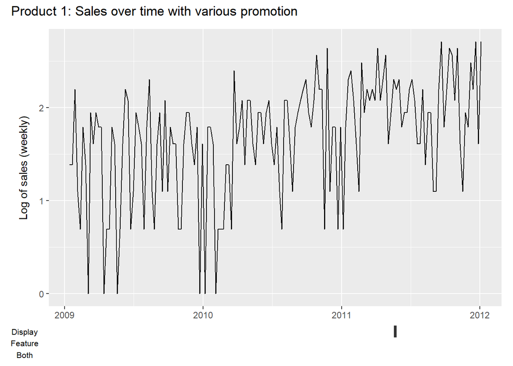

```r
p1.sales <- ggplot(wide_data3, aes(x=WEEK_END_DATE, y=LNSALES_Product1)) +
  geom_line() +
  theme(axis.title.x=element_blank()) +
  labs(y="Log of sales (weekly)")

p1.display <- ggplot(wide_data3) +
  geom_tile(aes(x=WEEK_END_DATE, y=DISPLAYONLY_Product1)) +
  coord_cartesian(ylim=c(0.9,1.1)) +
  theme_void() +
  theme(axis.title.y.left = element_text(size=8)) +
  labs(y="Display")

p1.feature <- ggplot(wide_data3) +
  geom_tile(aes(x=WEEK_END_DATE, y=FEATUREONLY_Product1)) +
  coord_cartesian(ylim=c(0.9,1.1)) +
  theme_void() +
  theme(axis.title.y.left = element_text(size=8)) +
  labs(y="Feature")

p1.both <- ggplot(wide_data3) +
  geom_tile(aes(x=WEEK_END_DATE, y=COMBINATION_Product1)) +
  coord_cartesian(ylim=c(0.9,1.1)) +
  theme_void() +
  theme(axis.title.y.left = element_text(size=8)) +
  labs(y="Both")

p1.all <- p1.sales + p1.display + p1.feature + p1.both +
  plot_layout(widths = 15, heights = c(12, 0.5, 0.5, 0.5)) +
  plot_annotation(
    title="Product 1: Sales over time with various promotion",
    theme=theme(
        plot.caption=element_text(face="italic"),
      )
    )

p1.all
```

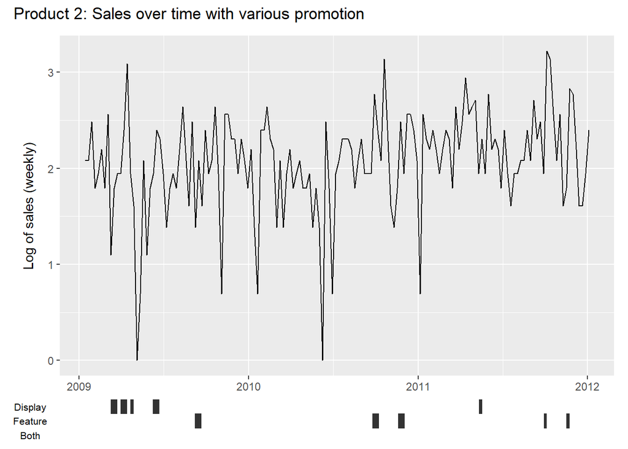

```r
p2.sales <- ggplot(wide_data3, aes(x=WEEK_END_DATE, y=LNSALES_Product2)) +
  geom_line() +
  theme(axis.title.x=element_blank()) +
  labs(y="Log of sales (weekly)")

p2.display <- ggplot(wide_data3) +
  geom_tile(aes(x=WEEK_END_DATE, y=DISPLAYONLY_Product2)) +
  coord_cartesian(ylim=c(0.9,1.1)) +
  theme_void() +
  theme(axis.title.y.left = element_text(size=8)) +
  labs(y="Display")

p2.feature <- ggplot(wide_data3) +
  geom_tile(aes(x=WEEK_END_DATE, y=FEATUREONLY_Product2)) +
  coord_cartesian(ylim=c(0.9,1.1)) +
  theme_void() +
  theme(axis.title.y.left = element_text(size=8)) +
  labs(y="Feature")

p2.both <- ggplot(wide_data3) +
  geom_tile(aes(x=WEEK_END_DATE, y=COMBINATION_Product2)) +
  coord_cartesian(ylim=c(0.9,1.1)) +
  theme_void() +
  theme(axis.title.y.left = element_text(size=8)) +
  labs(y="Both")

p2.all <- p2.sales + p2.display + p2.feature + p2.both +
  plot_layout(widths = 15, heights = c(12, 0.5, 0.5, 0.5)) +
  plot_annotation(
    title="Product 2: Sales over time with various promotion",
    theme=theme(
        plot.caption=element_text(face="italic"),
      )
    )

p2.all
```

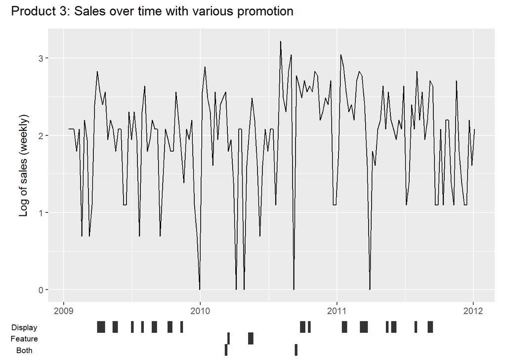

```r
p3.sales <- ggplot(wide_data3, aes(x=WEEK_END_DATE, y=LNSALES_Product3)) +
  geom_line() +
  theme(axis.title.x=element_blank()) +
  labs(y="Log of sales (weekly)")

p3.display <- ggplot(wide_data3) +
  geom_tile(aes(x=WEEK_END_DATE, y=DISPLAYONLY_Product3)) +
  coord_cartesian(ylim=c(0.9,1.1)) +
  theme_void() +
  theme(axis.title.y.left = element_text(size=8)) +
  labs(y="Display")

p3.feature <- ggplot(wide_data3) +
  geom_tile(aes(x=WEEK_END_DATE, y=FEATUREONLY_Product3)) +
  coord_cartesian(ylim=c(0.9,1.1)) +
  theme_void() +
  theme(axis.title.y.left = element_text(size=8)) +
  labs(y="Feature")

p3.both <- ggplot(wide_data3) +
  geom_tile(aes(x=WEEK_END_DATE, y=COMBINATION_Product3)) +
  coord_cartesian(ylim=c(0.9,1.1)) +
  theme_void() +
  theme(axis.title.y.left = element_text(size=8)) +
  labs(y="Both")

p3.all <- p3.sales + p3.display + p3.feature + p3.both +
  plot_layout(widths = 15, heights = c(12, 0.5, 0.5, 0.5)) +
  plot_annotation(
    title="Product 3: Sales over time with various promotion",
    theme=theme(
        plot.caption=element_text(face="italic"),
      )
    )

p3.all
```

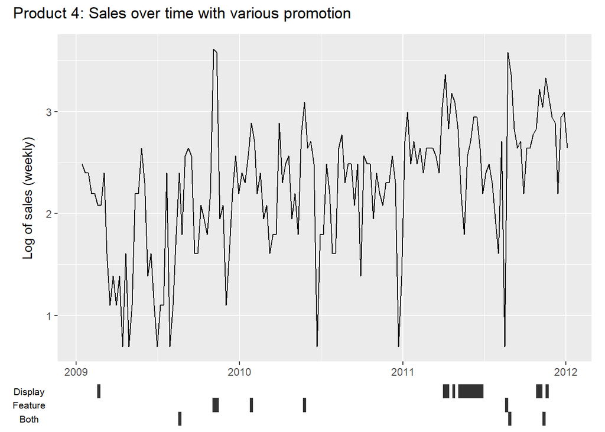

```r
p4.sales <- ggplot(wide_data3, aes(x=WEEK_END_DATE, y=LNSALES_Product4)) +
  geom_line() +
  theme(axis.title.x=element_blank()) +
  labs(y="Log of sales (weekly)")

p4.display <- ggplot(wide_data3) +
  geom_tile(aes(x=WEEK_END_DATE, y=DISPLAYONLY_Product4)) +
  coord_cartesian(ylim=c(0.9,1.1)) +
  theme_void() +
  theme(axis.title.y.left = element_text(size=8)) +
  labs(y="Display")

p4.feature <- ggplot(wide_data3) +
  geom_tile(aes(x=WEEK_END_DATE, y=FEATUREONLY_Product4)) +
  coord_cartesian(ylim=c(0.9,1.1)) +
  theme_void() +
  theme(axis.title.y.left = element_text(size=8)) +
  labs(y="Feature")

p4.both <- ggplot(wide_data3) +
  geom_tile(aes(x=WEEK_END_DATE, y=COMBINATION_Product4)) +
  coord_cartesian(ylim=c(0.9,1.1)) +
  theme_void() +
  theme(axis.title.y.left = element_text(size=8)) +
  labs(y="Both")

p4.all <- p4.sales + p4.display + p4.feature + p4.both +
  plot_layout(widths = 15, heights = c(12, 0.5, 0.5, 0.5)) +
  plot_annotation(
    title="Product 4: Sales over time with various promotion",
    theme=theme(
        plot.caption=element_text(face="italic"),
      )
    )

p4.all
```

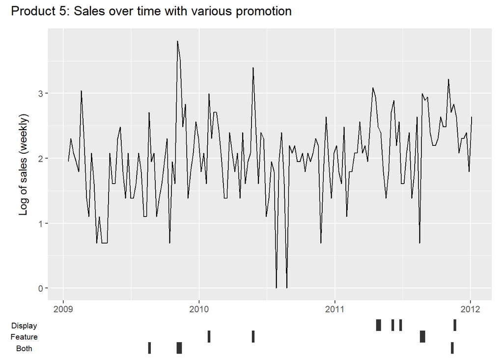

```r
p5.sales <- ggplot(wide_data3, aes(x=WEEK_END_DATE, y=LNSALES_Product5)) +
  geom_line() +
  theme(axis.title.x=element_blank()) +
  labs(y="Log of sales (weekly)")

p5.display <- ggplot(wide_data3) +
  geom_tile(aes(x=WEEK_END_DATE, y=DISPLAYONLY_Product5)) +
  coord_cartesian(ylim=c(0.9,1.1)) +
  theme_void() +
  theme(axis.title.y.left = element_text(size=8)) +
  labs(y="Display")

p5.feature <- ggplot(wide_data3) +
  geom_tile(aes(x=WEEK_END_DATE, y=FEATUREONLY_Product5)) +
  coord_cartesian(ylim=c(0.9,1.1)) +
  theme_void() +
  theme(axis.title.y.left = element_text(size=8)) +
  labs(y="Feature")

p5.both <- ggplot(wide_data3) +
  geom_tile(aes(x=WEEK_END_DATE, y=COMBINATION_Product5)) +
  coord_cartesian(ylim=c(0.9,1.1)) +
  theme_void() +
  theme(axis.title.y.left = element_text(size=8)) +
  labs(y="Both")

p5.all <- p5.sales + p5.display + p5.feature + p5.both +
  plot_layout(widths = 15, heights = c(12, 0.5, 0.5, 0.5)) +
  plot_annotation(
    title="Product 5: Sales over time with various promotion",
    theme=theme(
        plot.caption=element_text(face="italic"),
      )
    )

p5.all
```

# Further Experimentation

If we skip the missing value periods, we can attempt to perform a time-series analysis.

## seasonal-trend decomposition

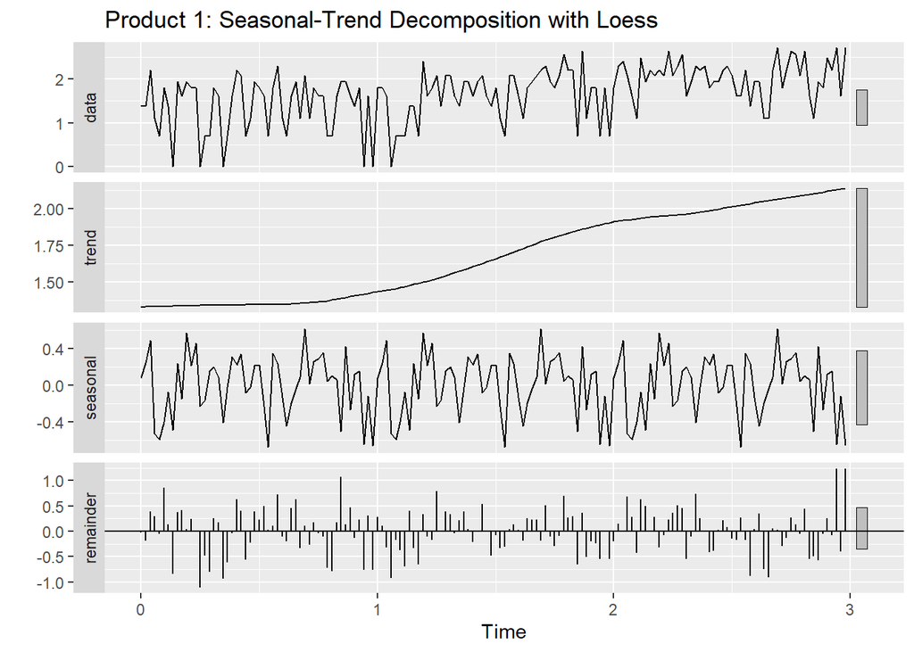

```r
tsdata <- ts(wide_data3, start=c(0,1), frequency=52)

tsdata[,2] %>%
  stl(s.window="periodic") %>%
  autoplot() + ggtitle("Product 1: Seasonal-Trend Decomposition with Loess")
```

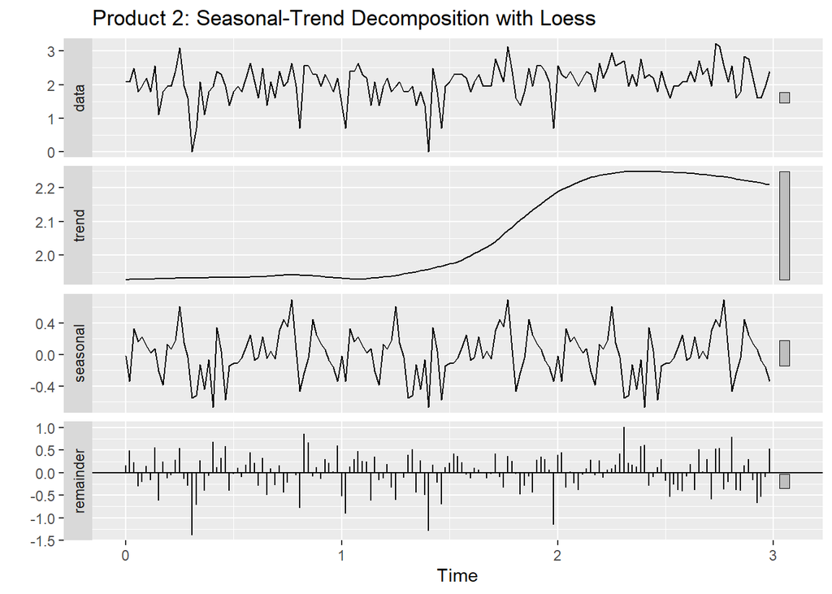

```r
tsdata[,3] %>%
  stl(s.window="periodic") %>%
  autoplot() + ggtitle("Product 2: Seasonal-Trend Decomposition with Loess")
```

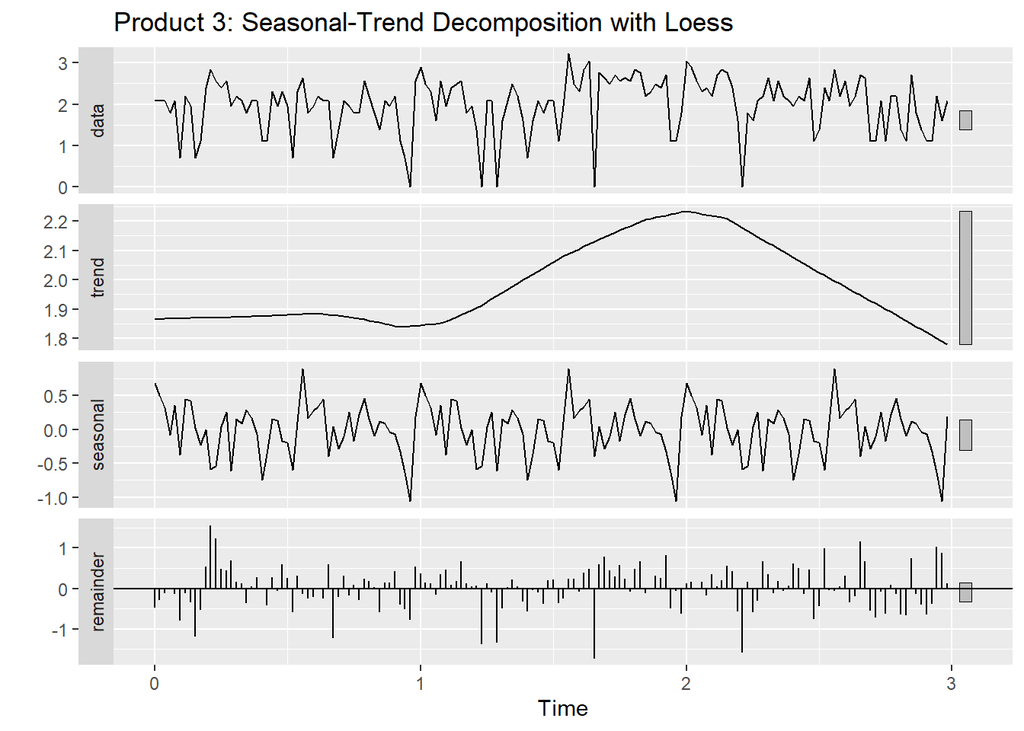

```r
tsdata[,4] %>%
  stl(s.window="periodic") %>%
  autoplot() + ggtitle("Product 3: Seasonal-Trend Decomposition with Loess")
```

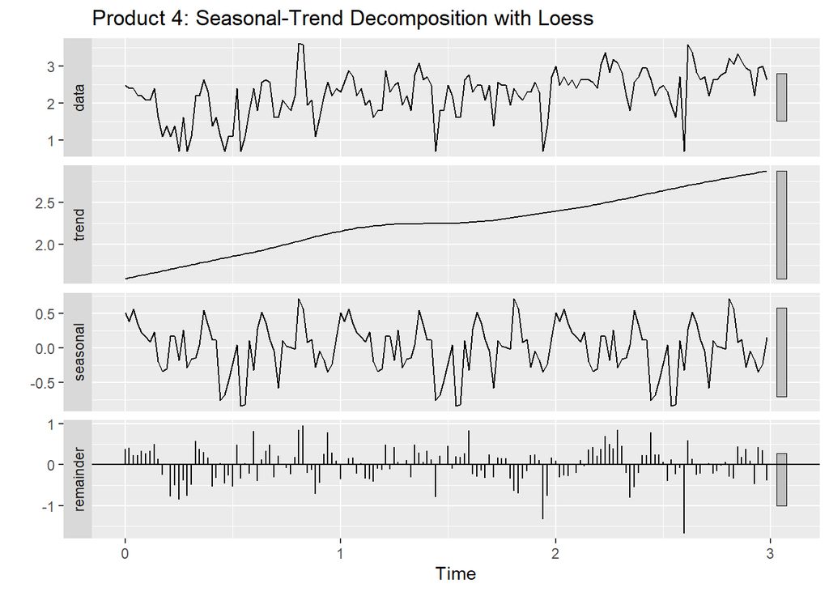

```r
tsdata[,5] %>%
  stl(s.window="periodic") %>%
  autoplot() + ggtitle("Product 4: Seasonal-Trend Decomposition with Loess")
```

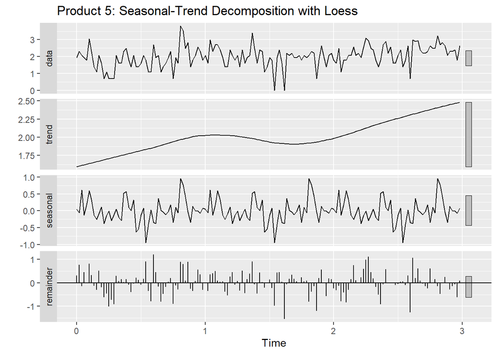

```r
tsdata[,6] %>%
  stl(s.window="periodic") %>%
  autoplot() + ggtitle("Product 5: Seasonal-Trend Decomposition with Loess")
```

Evaluation of STL decomposition:

- **Product 1**: Trend and seasonality are not significant, indicated by the long grey bar (more than the remainder term) on RHS
- **Product 2**: Trend is not significant, but there may be some seasonality
- **Product 3**: Similar to product 2, likely due to being on the same brand
- **Product 4**: Trend and seasonality are not significant
- **Product 5**: Trend is not significant, but there may be some seasonality

# Stationarity tests

```r
for (i in 2:6) {
  cat("<b>Product ", (i-1), "<\b><br>")
  print(adf.test(tsdata[,i]))
  print(pp.test(tsdata[,i]))
}
```

Product 1 <>  
Augmented Dickey-Fuller Test

data: tsdata[, i] Dickey-Fuller = -4.298, Lag order = 5, p-value = 0.01 alternative hypothesis: stationary

```
Phillips-Perron Unit Root Test
```

data: tsdata[, i] Dickey-Fuller Z(alpha) = -139.52, Truncation lag parameter = 4, p-value = 0.01 alternative hypothesis: stationary

Product 2 <>  
Augmented Dickey-Fuller Test

data: tsdata[, i] Dickey-Fuller = -5.2473, Lag order = 5, p-value = 0.01 alternative hypothesis: stationary

```
Phillips-Perron Unit Root Test
```

data: tsdata[, i] Dickey-Fuller Z(alpha) = -123.34, Truncation lag parameter = 4, p-value = 0.01 alternative hypothesis: stationary

Product 3 <>  
Augmented Dickey-Fuller Test

data: tsdata[, i] Dickey-Fuller = -4.1306, Lag order = 5, p-value = 0.01 alternative hypothesis: stationary

```
Phillips-Perron Unit Root Test
```

data: tsdata[, i] Dickey-Fuller Z(alpha) = -110.69, Truncation lag parameter = 4, p-value = 0.01 alternative hypothesis: stationary

Product 4 <>  
Augmented Dickey-Fuller Test

data: tsdata[, i] Dickey-Fuller = -5.199, Lag order = 5, p-value = 0.01 alternative hypothesis: stationary

```
Phillips-Perron Unit Root Test
```

data: tsdata[, i] Dickey-Fuller Z(alpha) = -94.173, Truncation lag parameter = 4, p-value = 0.01 alternative hypothesis: stationary

Product 5 <>  
Augmented Dickey-Fuller Test

data: tsdata[, i] Dickey-Fuller = -4.8558, Lag order = 5, p-value = 0.01 alternative hypothesis: stationary

```
Phillips-Perron Unit Root Test
```

data: tsdata[, i] Dickey-Fuller Z(alpha) = -118.97, Truncation lag parameter = 4, p-value = 0.01 alternative hypothesis: stationary

## Product 1

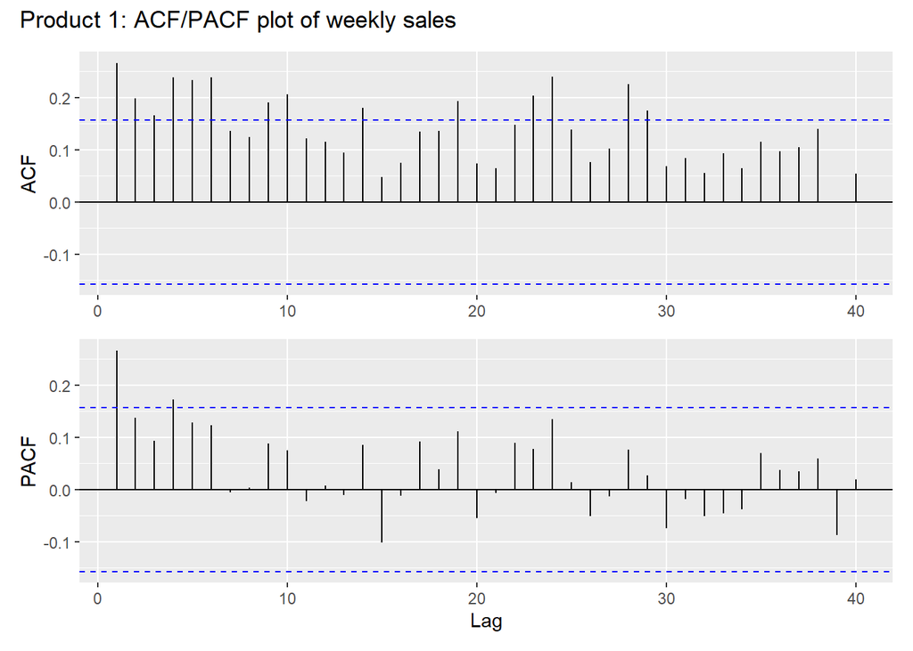

```r
p1.acf <- ggAcf(tsdata[,2], lag.max=40) +
  theme(plot.title=element_blank(), axis.title.x=element_blank())
p1.pacf <- ggPacf(tsdata[,2], lag.max=40) +
  theme(plot.title=element_blank())

p1.acf / p1.pacf +
  plot_annotation(title="Product 1: ACF/PACF plot of weekly sales")
```

```r
cat("Non-seasonal order of difference:", ndiffs(tsdata[,2]))
```

```
## Non-seasonal order of difference: 1
```

```r
cat("Seasonal order of difference:", nsdiffs(tsdata[,2]))
```

```
## Seasonal order of difference: 0
```

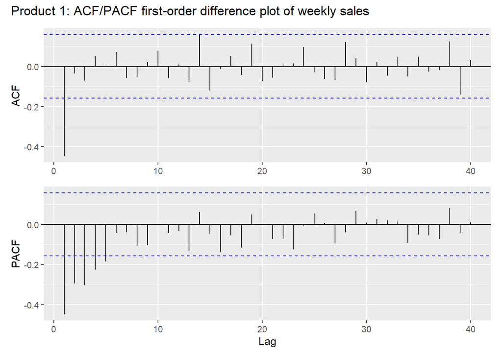

```r
p1.acf2 <- ggAcf(diff(tsdata[,2]), lag.max=40) +
  theme(plot.title=element_blank(), axis.title.x=element_blank())
p1.pacf2 <- ggPacf(diff(tsdata[,2]), lag.max=40) +
  theme(plot.title=element_blank())

p1.acf2 / p1.pacf2 +
  plot_annotation(title="Product 1: ACF/PACF first-order difference plot of weekly sales")
```

ACF cuts off at lag 1 with 1st order differencing, indicating AR(1) term. PACF tails off.

## Product 2

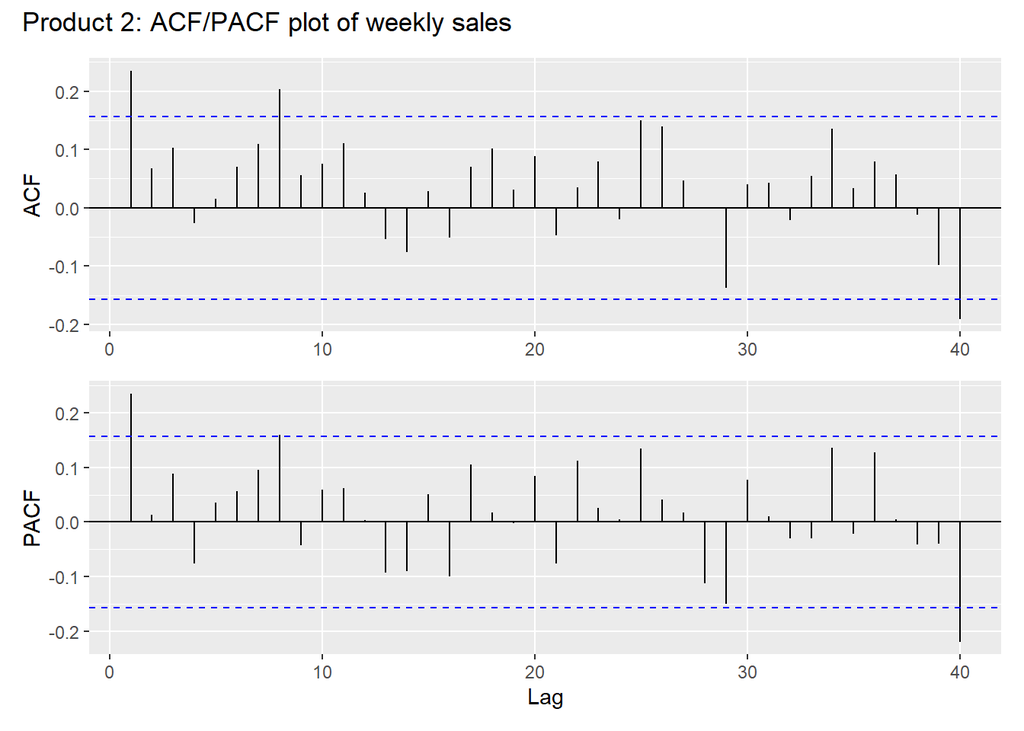

```r
p2.acf <- ggAcf(tsdata[,3], lag.max=40) +
  theme(plot.title=element_blank(), axis.title.x=element_blank())
p2.pacf <- ggPacf(tsdata[,3], lag.max=40) +
  theme(plot.title=element_blank())

p2.acf / p2.pacf +
  plot_annotation(title="Product 2: ACF/PACF plot of weekly sales")
```

PACF and ACF cut off at lag 1 indicating AR(1) and MA(1) terms

```r
cat("Non-seasonal order of difference:", ndiffs(tsdata[,3]))
```

```
## Non-seasonal order of difference: 1
```

```r
cat("Seasonal order of difference:", nsdiffs(tsdata[,3]))
```

```
## Seasonal order of difference: 0
```

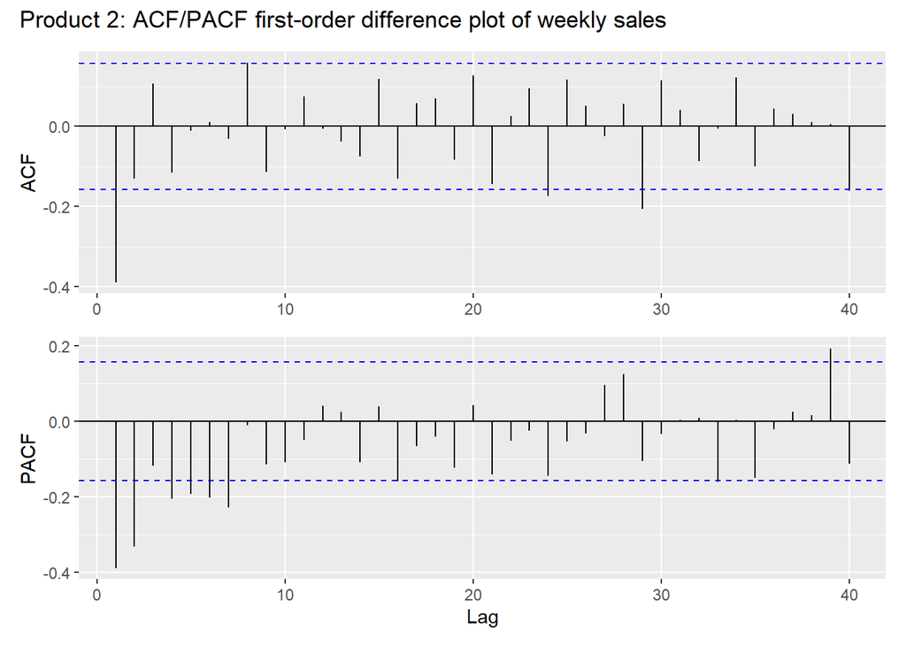

```r
p2.acf2 <- ggAcf(diff(tsdata[,3]), lag.max=40) +
  theme(plot.title=element_blank(), axis.title.x=element_blank())
p2.pacf2 <- ggPacf(diff(tsdata[,3]), lag.max=40) +
  theme(plot.title=element_blank())

p2.acf2 / p2.pacf2 +
  plot_annotation(title="Product 2: ACF/PACF first-order difference plot of weekly sales")
```

ACF cuts off at lag 1 with 1st order differencing, indicating AR(1) term. PACF tails off.